# AIML_ML_Project_full_code_notebook_Rohit_Kumar

## Problem Statement

### Context

AllLife Bank is a US bank that has a growing customer base. The majority of these customers are liability customers (depositors) with varying sizes of deposits. The number of customers who are also borrowers (asset customers) is quite small, and the bank is interested in expanding this base rapidly to bring in more loan business and in the process, earn more through the interest on loans. In particular, the management wants to explore ways of converting its liability customers to personal loan customers (while retaining them as depositors).

A campaign that the bank ran last year for liability customers showed a healthy conversion rate of over 9% success. This has encouraged the retail marketing department to devise campaigns with better target marketing to increase the success ratio.

You as a Data scientist at AllLife bank have to build a model that will help the marketing department to identify the potential customers who have a higher probability of purchasing the loan.

### Objective

To predict whether a liability customer will buy personal loans, to understand which customer attributes are most significant in driving purchases, and identify which segment of customers to target more.

### Data Dictionary

- `ID`: Customer ID
- `Age`: Customer’s age in completed years
- `Experience`: #years of professional experience
- `Income`: Annual income of the customer (in thousand dollars)
- `ZIP Code`: Home Address ZIP code.
- `Family`: the Family size of the customer
- `CCAvg`: Average spending on credit cards per month (in thousand dollars)
- `Education`: Education Level. 1: Undergrad; 2: Graduate;3: Advanced/Professional
- `Mortgage`: Value of house mortgage if any. (in thousand dollars)
- `Personal_Loan`: Did this customer accept the personal loan offered in the last campaign? (0: No, 1: Yes)
- `Securities_Account`: Does the customer have securities account with the bank? (0: No, 1: Yes)
- `CD_Account`: Does the customer have a certificate of deposit (CD) account with the bank? (0: No, 1: Yes)
- `Online`: Do customers use internet banking facilities? (0: No, 1: Yes)
- `CreditCard`: Does the customer use a credit card issued by any other Bank (excluding All life Bank)? (0: No, 1: Yes)

## Importing necessary libraries

```python
# Installing the libraries with the specified version.
!pip install numpy==1.25.2 pandas==1.5.3 matplotlib==3.7.1 seaborn==0.13.1 scikit-learn==1.2.2 sklearn-pandas==2.2.0 -q --user
```

**Note**:

1. After running the above cell, kindly restart the notebook kernel (for Jupyter Notebook) or runtime (for Google Colab), write the relevant code for the project from the next cell, and run all cells sequentially from the next cell.
2. On executing the above line of code, you might see a warning regarding package dependencies. This error message can be ignored as the above code ensures that all necessary libraries and their dependencies are maintained to successfully execute the code in this notebook.

```python
# Libraries for reading and manipulating data

import numpy as np
import pandas as pd
# libaries to help with data visualization
import matplotlib.pyplot as plt
import seaborn as sns
import warnings

# Library to split data
from sklearn.model_selection import train_test_split

# To build model for prediction
from sklearn.tree import DecisionTreeClassifier
from sklearn import tree
from sklearn.metrics import classification_report
from sklearn.tree import plot_tree

# To get diferent metric scores
from sklearn.metrics import (
    f1_score,
    accuracy_score,
    recall_score,
    precision_score,
    confusion_matrix,
)
#filter warnings
warnings.filterwarnings("ignore")
```

## Loading the dataset

```python
# Mounting the Google Drive in a Google Colab environment
from google.colab import drive
drive.mount('/content/drive')
```

```python
# Loading the csv file from the drive
loan_data=pd.read_csv('/content/drive/MyDrive/Loan_Modelling.csv')
```

```python
# Copy the data to another variable
data=loan_data.copy();
```

## Data Overview

- Observations
- Sanity checks

**View First 5 Rows**

```python
# View first 5 rows
data.head(5)
```

|  | ID | Age | Experience | Income | ZIPCode | Family | CCAvg | Education | Mortgage | Personal_Loan | Securities_Account | CD_Account | Online | CreditCard |
| --- | --- | --- | --- | --- | --- | --- | --- | --- | --- | --- | --- | --- | --- | --- |
| 0 | 1 | 25 | 1 | 49 | 91107 | 4 | 1.6 | 1 | 0 | 0 | 1 | 0 | 0 | 0 |
| 1 | 2 | 45 | 19 | 34 | 90089 | 3 | 1.5 | 1 | 0 | 0 | 1 | 0 | 0 | 0 |
| 2 | 3 | 39 | 15 | 11 | 94720 | 1 | 1.0 | 1 | 0 | 0 | 0 | 0 | 0 | 0 |
| 3 | 4 | 35 | 9 | 100 | 94112 | 1 | 2.7 | 2 | 0 | 0 | 0 | 0 | 0 | 0 |
| 4 | 5 | 35 | 8 | 45 | 91330 | 4 | 1.0 | 2 | 0 | 0 | 0 | 0 | 0 | 1 |

**Shape of the dataset**

```python
data.shape
```

```
(5000, 14)
```

Observations :-

- The dataset contains 5000 rows and 14 columns.

**Data types of the Columns of the dataset**

```python
data.info()
```

```
<class 'pandas.core.frame.DataFrame'>
RangeIndex: 5000 entries, 0 to 4999
Data columns (total 14 columns):
 #   Column              Non-Null Count  Dtype
---  ------              --------------  -----
 0   ID                  5000 non-null   int64
 1   Age                 5000 non-null   int64
 2   Experience          5000 non-null   int64
 3   Income              5000 non-null   int64
 4   ZIPCode             5000 non-null   int64
 5   Family              5000 non-null   int64
 6   CCAvg               5000 non-null   float64
 7   Education           5000 non-null   int64
 8   Mortgage            5000 non-null   int64
 9   Personal_Loan       5000 non-null   int64
 10  Securities_Account  5000 non-null   int64
 11  CD_Account          5000 non-null   int64
 12  Online              5000 non-null   int64
 13  CreditCard          5000 non-null   int64
dtypes: float64(1), int64(13)
memory usage: 547.0 KB
```

Obsevations :-

- All columns have 5000 observations (non-null values), which indicates no missing values in the dataset.
- There are 13 columns with Int data types and 1 float column.
- Most features are numeric, including Age, Experience, Income, Family, CCAvg, Mortgage.
- Some features are categorical but stored as integers (Education, Securities_Account, CD_Account, Online, CreditCard).
- Experience column contains negative values, which are invalid (sanity check needed).

**Check for Missing value in dataset**

```python
data.isnull().sum()
```

|  | 0 |
| --- | --- |
| ID | 0 |
| Age | 0 |
| Experience | 0 |
| Income | 0 |
| ZIPCode | 0 |
| Family | 0 |
| CCAvg | 0 |
| Education | 0 |
| Mortgage | 0 |
| Personal_Loan | 0 |
| Securities_Account | 0 |
| CD_Account | 0 |
| Online | 0 |
| CreditCard | 0 |

**dtype:** int64

Observations:

- There are no null values in any of the columns in the dataset.
- Howerver, Experience column contains negative values, which are invalid (sanity check needed)

**Check for duplicate record in the dataset**

```python
data.duplicated().sum()
```

```
0
```

Observations:

- There are no duplicate records in the dataset.

**Summary Statistics**

```python
data.describe().T
```

|  | count | mean | std | min | 25% | 50% | 75% | max |
| --- | --- | --- | --- | --- | --- | --- | --- | --- |
| ID | 5000.0 | 2500.500000 | 1443.520003 | 1.0 | 1250.75 | 2500.5 | 3750.25 | 5000.0 |
| Age | 5000.0 | 45.338400 | 11.463166 | 23.0 | 35.00 | 45.0 | 55.00 | 67.0 |
| Experience | 5000.0 | 20.104600 | 11.467954 | -3.0 | 10.00 | 20.0 | 30.00 | 43.0 |
| Income | 5000.0 | 73.774200 | 46.033729 | 8.0 | 39.00 | 64.0 | 98.00 | 224.0 |
| ZIPCode | 5000.0 | 93169.257000 | 1759.455086 | 90005.0 | 91911.00 | 93437.0 | 94608.00 | 96651.0 |
| Family | 5000.0 | 2.396400 | 1.147663 | 1.0 | 1.00 | 2.0 | 3.00 | 4.0 |
| CCAvg | 5000.0 | 1.937938 | 1.747659 | 0.0 | 0.70 | 1.5 | 2.50 | 10.0 |
| Education | 5000.0 | 1.881000 | 0.839869 | 1.0 | 1.00 | 2.0 | 3.00 | 3.0 |
| Mortgage | 5000.0 | 56.498800 | 101.713802 | 0.0 | 0.00 | 0.0 | 101.00 | 635.0 |
| Personal_Loan | 5000.0 | 0.096000 | 0.294621 | 0.0 | 0.00 | 0.0 | 0.00 | 1.0 |
| Securities_Account | 5000.0 | 0.104400 | 0.305809 | 0.0 | 0.00 | 0.0 | 0.00 | 1.0 |
| CD_Account | 5000.0 | 0.060400 | 0.238250 | 0.0 | 0.00 | 0.0 | 0.00 | 1.0 |
| Online | 5000.0 | 0.596800 | 0.490589 | 0.0 | 0.00 | 1.0 | 1.00 | 1.0 |
| CreditCard | 5000.0 | 0.294000 | 0.455637 | 0.0 | 0.00 | 0.0 | 1.00 | 1.0 |

Observations :-

- Age ranges from 23 years to 67 years. Median age is 45 years whch means middle age customer base.
- Experience has minmum as -3 which is invalid and needs to be cleaned.
- Income ranges from 8,000 to 224,000 with mean income as 73,774.
- A significant portion of customers have no mortgage (50th percentile = 0).Max mortgage is $635,000, indicating a few customers have very high mortgages.

**Data Cleaning**

```python
# Dropping column -- ID
data=data.drop(['ID'], axis=1)
```

```python
# Checking for no of negative Experience
negative_experience=data[data["Experience"] < 0]['Experience'].unique()
print('Negative Experience :- ', negative_experience)
# Correcting negative values in 'Experience' Column
data['Experience'] = data['Experience'].apply(lambda x: abs(x) if x < 0 else x)
# Checking for no of negative Experience
negative_experience=data[data["Experience"] < 0]['Experience'].unique()
print('Negative Experience :- ', negative_experience)
```

```
Negative Experience :-  [-1 -2 -3]
Negative Experience :-  []
```

```python
# Converting the Categorical features to category
category_columns=['Education', 'Securities_Account', 'CD_Account', 'Online', 'CreditCard','ZIPCode','Personal_Loan']
data[category_columns]=data[category_columns].astype("category")
```

## Exploratory Data Analysis.

- EDA is an important part of any project involving data.
- It is important to investigate and understand the data better before building a model with it.
- A few questions have been mentioned below which will help you approach the analysis in the right manner and generate insights from the data.
- A thorough analysis of the data, in addition to the questions mentioned below, should be done.

**Questions**:

1. What is the distribution of mortgage attribute? Are there any noticeable patterns or outliers in the distribution?
2. How many customers have credit cards?
3. What are the attributes that have a strong correlation with the target attribute (personal loan)?
4. How does a customer's interest in purchasing a loan vary with their age?
5. How does a customer's interest in purchasing a loan vary with their education?

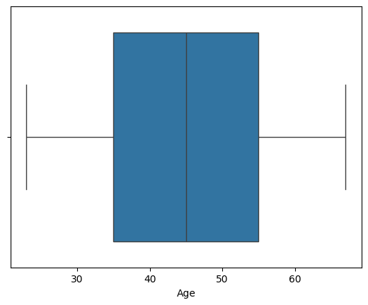

```python
# Box plot for the Age
sns.boxplot(data=data,x='Age')
plt.show()
```

Observations :-

- The age values range approximately from 20 to 65 years.
- There are no significant extreme outliers, indicating that the age data is fairly normally distributed

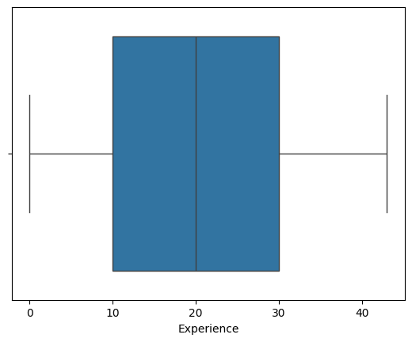

```python
# Box plot for the Experience
sns.boxplot(data=data,x='Experience')
plt.show()
```

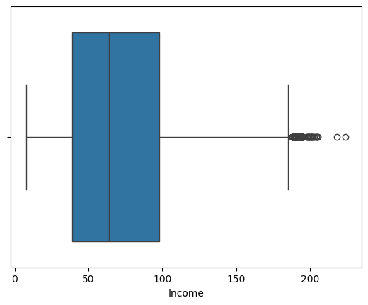

```python
# Box plot for the  Income
sns.boxplot(data=data,x='Income')
plt.show()
```

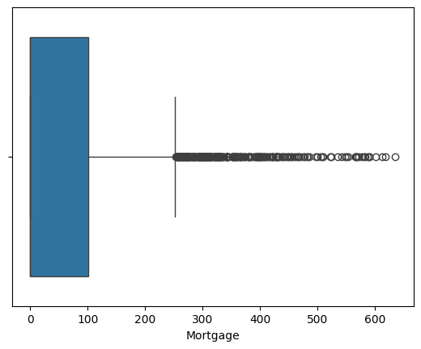

```python
# Box plot for the  Mortgage
sns.boxplot(data=data,x='Mortgage')
plt.show()
```

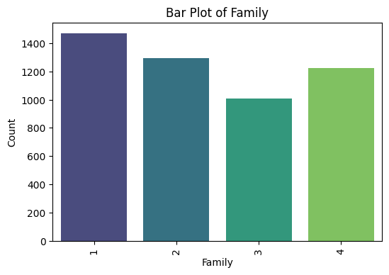

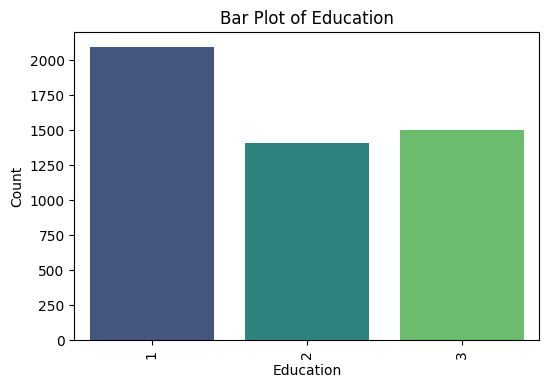

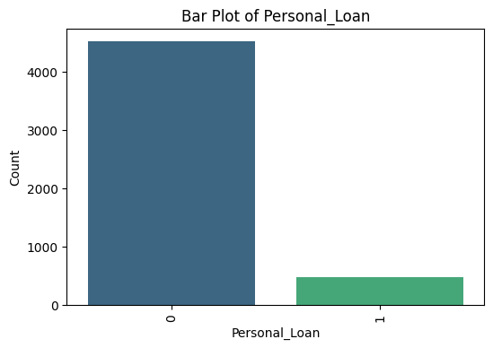

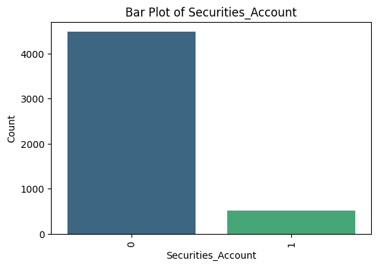

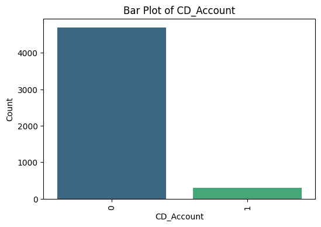

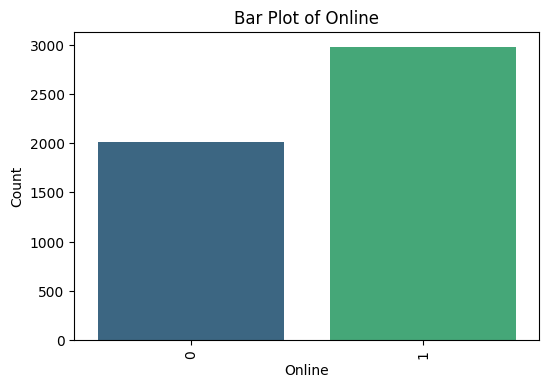

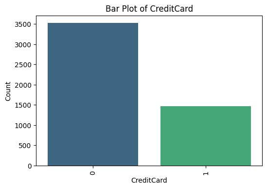

```python
# Creating barplots for the categorical columns
categorical_cols = ['Family', 'Education', 'Personal_Loan', 'Securities_Account','CD_Account', 'Online', 'CreditCard']
# Creating bar plots for categorical variables
for column in categorical_cols:
    plt.figure(figsize=(6, 4))
    sns.countplot(x=data[column], palette="viridis")
    plt.xlabel(column)
    plt.ylabel('Count')
    plt.title(f'Bar Plot of {column}')
    plt.xticks(rotation=90)
    plt.show()
```

Observation -

- The dataset likely has three education levels, with one category being more dominant .
- The majority of people do not have a personal loan (0), while a smaller percentage have taken one (1).
- This suggests that most individuals in the dataset may not require personal loans or are not approved for them.
- The bar plot might indicate that most individuals do not have a securities account (0)
- As Securities Account, a majority of customers do not have a CD account.This could imply that CD accounts are less popular.
- Barplot suggests that while online banking is prevalent, a portion of users still prefer traditional banking methods.
- The distribution shows that many customers do not have a credit card (0), but a sizable number do (1).This could indicate that customers in the dataset might have varying financial habits regarding credit usage.

**Bivariate Analysis**

[figure not shown]

```python
#
correlation_matrix = data.drop(columns=['ID']).corr()
plt.figure(figsize=(10,6))
sns.heatmap(correlation_matrix,annot=True, vmin=-1, vmax=1, fmt=".2f", cmap="Spectral")
plt.show()
```

Observations :-

**Bivariate Analysis between numerical columns("Age", "Experience", "Income", "CCAvg", "Mortgage") and Target variable(Personal Loan)**

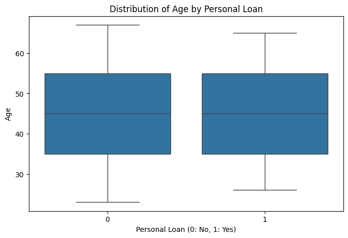

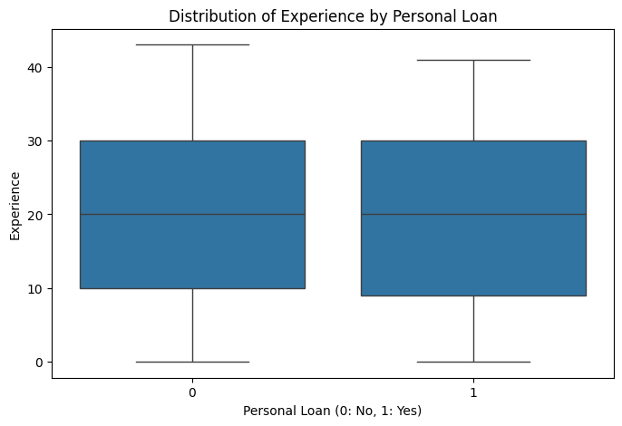

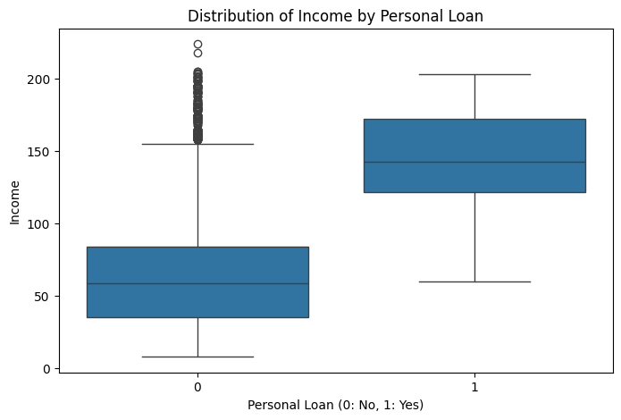

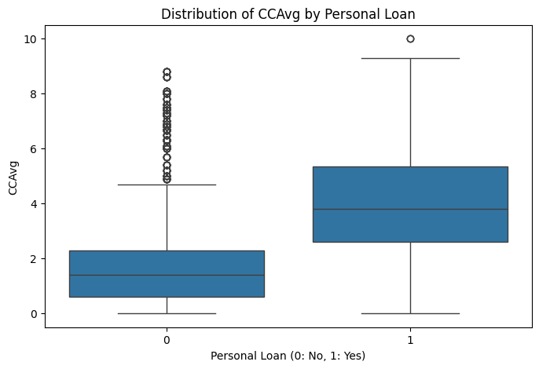

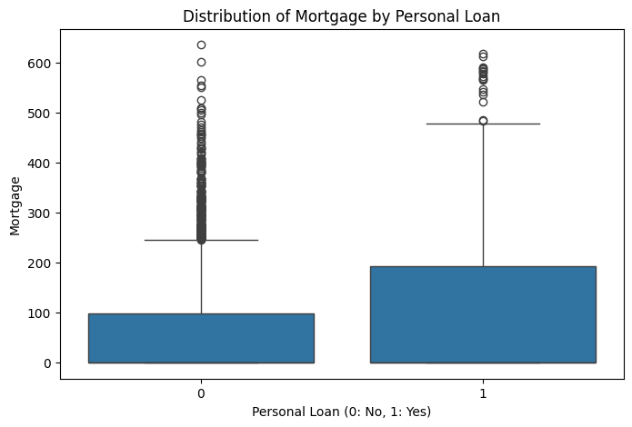

```python
numerical_cols = ['Age', 'Experience', 'Income', 'CCAvg', 'Mortgage']
for column in numerical_cols:
    plt.figure(figsize=(8, 5))
    sns.boxplot(x=data['Personal_Loan'], y=data[column])
    plt.title(f"Distribution of {column} by Personal Loan")
    plt.xlabel("Personal Loan (0: No, 1: Yes)")
    plt.ylabel(column)
    plt.show()
```

**Bivariate Analysis between Categorical columns("Family", "Education", "Securities_Account", "CD_Account", "Online", "CreditCard") and Target variable(Personal Loan)**

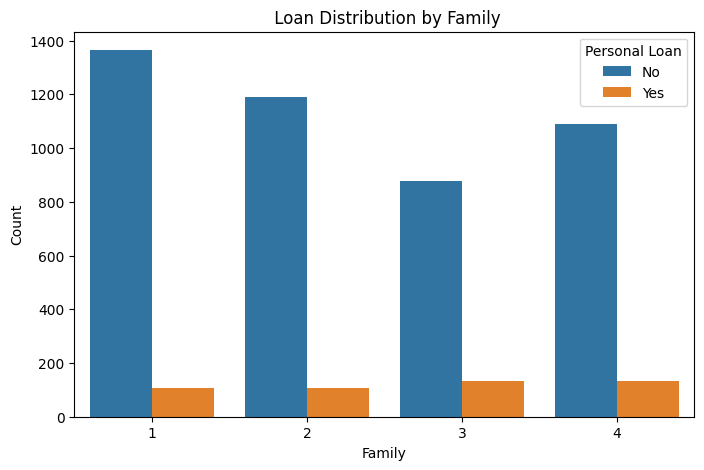

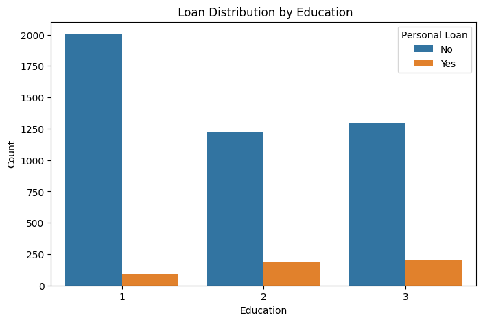

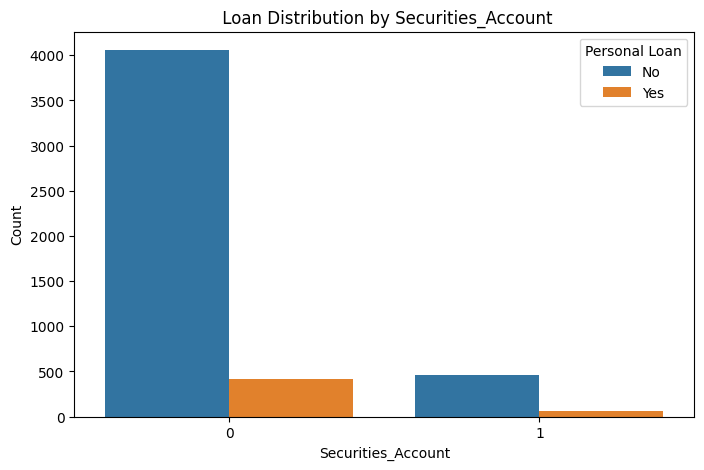

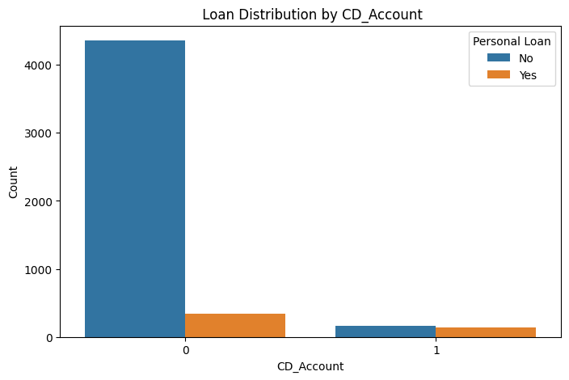

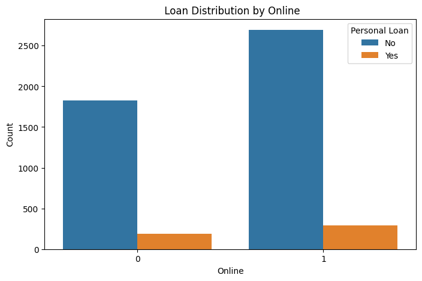

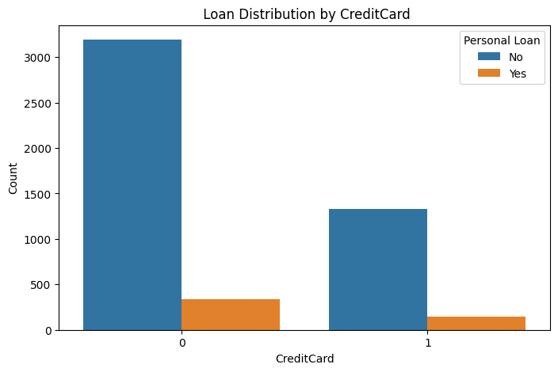

```python
categorical_cols = ["Family", "Education", "Securities_Account", "CD_Account", "Online", "CreditCard"]
for column in categorical_cols:
    plt.figure(figsize=(8, 5))
    sns.countplot(x=data[column], hue=data["Personal_Loan"])
    plt.title(f" Loan Distribution by {column}")
    plt.xlabel(column)
    plt.ylabel("Count")
    plt.legend(title="Personal Loan", labels=["No", "Yes"])
    plt.show()
```

Observations :-

Numerical Features:

Categorical Features:

## Data Preprocessing

- Missing value treatment
- Feature engineering (if needed)
- Outlier detection and treatment (if needed)
- Preparing data for modeling
- Any other preprocessing steps (if needed)

```python
Q1 = data.select_dtypes(include=["float64", "int64"]).quantile(0.25)
Q3 = data.select_dtypes(include=["float64", "int64"]).quantile(0.75)

IQR = Q3 - Q1

lower = Q1 - 1.5 * IQR
upper = Q3 + 1.5 * IQR

outliers = (
    (data.select_dtypes(include=["float64", "int64"]) < lower) |
    (data.select_dtypes(include=["float64", "int64"]) > upper)
)

outlier_percentage = outliers.sum() / len(data) * 100

print("Percentage of Outliers in Each Column:\n", outlier_percentage)
```

[output not shown]

**Data Preparation**

```python
# Data Preparation
X = data.drop(columns=["Personal_Loan"])  # Features
Y = data["Personal_Loan"]  # Target
# Split data into training (70%) and testing (30%)
X_train, X_test, Y_train, Y_test = train_test_split(X, Y, test_size=0.3, random_state=1)
# Print dataset shapes
print(f"X_train shape: {X_train.shape}, X_test shape: {X_test.shape}")
print(f"Y_train shape: {Y_train.shape}, Y_test shape: {Y_test.shape}")
print("Display the percentage of classes in train data",Y_train.value_counts(normalize = True))
print("Display the percentage of classes in test data",Y_test.value_counts(normalize = True))
```

[output not shown]

Observation :-

## Model Building

```python
#using sklearn compute different metrics to check performance of a classification model
def model_perf_class_sklearn(model, predictors, target):
    """
    Function to compute different metrics to check classification model performance

    model: classifier
    predictors: independent variables
    target: dependent variable
    """

    # predicting using the independent variables
    pred = model.predict(predictors)

    acc = accuracy_score(target, pred)  # to compute Accuracy
    recall = recall_score(target, pred)  # to compute Recall
    precision = precision_score(target, pred)  # to compute Precision
    f1 = f1_score(target, pred)  # to compute F1-score

    # creating a dataframe of metrics
    df_perf = pd.DataFrame(
        {"Accuracy": acc, "Recall": recall, "Precision": precision, "F1": f1,},
        index=[0],
    )

    return df_perf

def display_confusion_matrix_sklearn(model, predictors, target):
    """
    To plot the confusion_matrix with percentages

    model: classifier
    predictors: independent variables
    target: dependent variable
    """
    y_pred = model.predict(predictors)
    cm = confusion_matrix(target, y_pred)
    labels = np.asarray(
        [
            ["{0:0.0f}".format(item) + "\n{0:.2%}".format(item / cm.flatten().sum())]
            for item in cm.flatten()
        ]
    ).reshape(2, 2)

    plt.figure(figsize=(6, 4))
    sns.heatmap(cm, annot=labels, fmt="")
    plt.ylabel("True label")
    plt.xlabel("Predicted label")
```

```python
def show_feature_importance(importances, indices, feature_names):
  '''
  Description: Function to plot the features in the order of importance
  Parameters:
    importances: sklearn.tree.DecisionTreeClassifier, required
      The DataFrame of the two-dimensional tabular data

    indices: numpy.ndarray, required
      The indices of array

    feature_names: list, required
      The column names of features
  '''
  plt.figure(figsize = (12, 5))
  plt.title('Feature Importances', fontsize = 11)
  plt.barh(range(len(indices)), importances[indices], color = 'violet', align = 'center')
  plt.yticks(range(len(indices)), [feature_names[i] for i in indices])
  plt.xlabel('Relative Importance')

  plt.show()
```